# Relatório de Execução de piRNAcalc() para o chrY

José Roberto Sobrinho Lima

16 de April de 2018

## Introdução

Este relatório consiste na caracterização da função `piRNAcalc(vcf_file, gff_file)` definida no código-fonte [`piRNAmethods.R`](https://github.com/JsRoberto/piRNAproject/piRNAmethods.R) quando executada para o cromossomo chrY. Serão destacados:

1. Os tempos de execução das principais etapas do programa; e
2. Os resultados produzidos pela função:
- Um objeto R que armazena os dados da quantificação das mutações em piRNAs; e
- Um relatório de execução para o cromossomo chrY.

## Objeto da classe `PirnaGDF` ( *Genomes* *Data* *Format* )

O resultado obtido pela função `piRNAcalc(vcf_file, gff_file)` é um objeto S4 [(GENOLINI,2008)](https://cran.r-project.org/doc/contrib/Genolini-S4tutorialV0-5en.pdf) da classe `PirnaGDF`, definida no arquivo [`PirnaGDF-class.R`](https://github.com/JsRoberto/piRNAproject/PirnaGDF-class.R). O repositório local do [GitHub](https://github.com/JsRoberto/piRNAproject) no servidor armazenou o objeto gerado, `pirnaGDFchrY.rds`, que apresenta 6 *slots* (ou variáveis): `generalInfo` é o primeiro *slot* e contém informações gerais a respeito do objeto; os outros 5 *slots* contêm informações sobre cada uma das 5 regiões alvo (região de piRNA e outras 4 adjacentes de mesmo tamanho, nas vizinhanças 5’ e 3’ e a 1000 bases de distância nos dois sentidos da fita) e são da classe `InfoPirna`. Objetos da classe `InfoPirna` armazenam:

1. Uma tabela com informações sobre os piRNAs – nome, posição genômica e quatidade de mutações; e
2. Uma lista com informações sobre as mutações de cada piRNA – identificador NCBI, posição genômica, alteração em relação à referência, tipo de mutação, frequências e números de alelos em cada população humana.

```
* ========--------------------------- Classe PirnaGDF, método show ---------------------------========
* Informações Gerais =
#' @título Quantificação de mutações SNP e INDEL em regiões de piRNA e adjacentes em indivíduos
#' sequenciados pelo 1000 Genomes Project.

#' @descrição
#' O objeto PirnaGDFchrY pertence à classe PirnaGDF, que é basicamente a reunião de vários objetos
#' da classe InfoPirna, um para cada região alvo da análise; ambas estão definidas no arquivo
#' PirnaGDF-class.R

#' @detalhes
#' O objeto PirnaGDFchrY possui 6 slots:

#' @slot "generalInfo" apresenta título, descrição e detalhes do objeto.

#' @slot "adjRegion:piRNA" objeto da classe InfoPirna que apresenta (1) uma tabela com informações
#' sobre os piRNAs -- nome, posição genômica e quantidade de mutações; (2) uma lista correlacionada
#' com informações sobre as mutações de cada piRNA -- identificador NCBI, posição genômica,
#' alteração em relação à referência, tipo de mutação, frequências e números de alelos em cada
#' população humana.

#' @slot "adjRegion:+1000" objeto da classe InfoPirna, ou seja, apresenta as mesmas características
#' de "adjRegion:piRNA", sendo que em uma região de mesmo tamanho do piRNA correspondente com
#' 1000bases forward na fita de DNA.

#' @slot "adjRegion:-1000" objeto da classe InfoPirna, ou seja, apresenta as mesmas características
#' de "adjRegion:piRNA", sendo que em uma região de mesmo tamanho do piRNA correspondente com
#' 1000bases backward na fita de DNA.

#' @slot "adjRegion:3'" objeto da classe InfoPirna, ou seja, apresenta as mesmas características de
#' "adjRegion:piRNA", sendo que em uma região adjacente 3' de mesmo tamanho do piRNA correspondente.

#' @slot "adjRegion:5'" objeto da classe InfoPirna, ou seja, apresenta as mesmas características de
#' "adjRegion:piRNA", sendo que em uma região adjacente 5' de mesmo tamanho do piRNA correspondente.
#
*
* Dados para a região de piRNA (os 5 primeiros piRNAs mutados) =
* 1) Dados sobre cada piRNA ('pirnaData') =
*
'data.frame':   5 obs. of  7 variables:
```

[output cut: 105 more lines]

```
  ..$ Africano.AF       : chr "0.0016"
  ..$ Americano.AC      : num 0
  ..$ Americano.AF      : chr "0.0000"
  ..$ Leste Asiático.AC : num 0
  ..$ Leste Asiático.AF : chr "0.0000"
  ..$ Europeu.AC        : num 0
  ..$ Europeu.AF        : chr "0.0000"
  ..$ Sul Asiático.AC   : num 0
  ..$ Sul Asiático.AF   : chr "0.0000"
  ..- attr(*, "sorted")= chr [1:17] "Mutação.Cromossomo" "Mutação.Local" "Mutação.ID" "Alelo.Referência" ...
  ..- attr(*, ".internal.selfref")=<externalptr>
* -----------------------------------------------------------------------------------------------------
* OBS.: os dados para as regiões adjacentes foram omitidos para obter maior coesão e melhorar a
* visualização do método 'show' para objetos da classe PirnaGDF.
* ========--------------------------- Fim do método show (PirnaGDF) ---------------------------========
```

Em regiões de piRNA, podemos extrair uma série de informações a respeito de mutações.

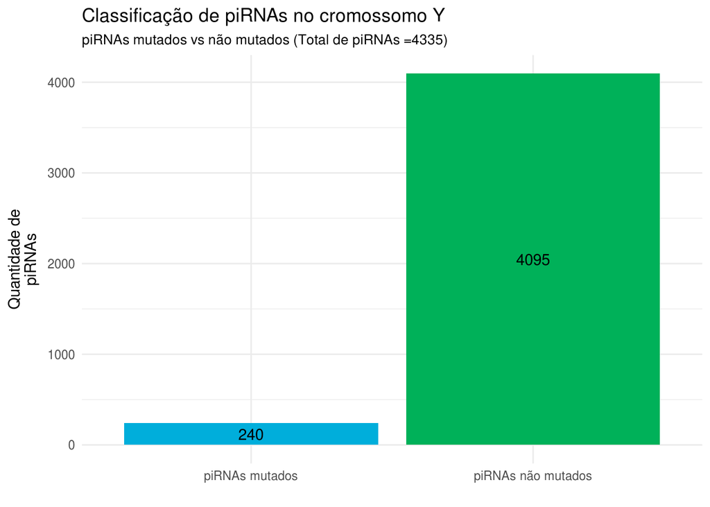

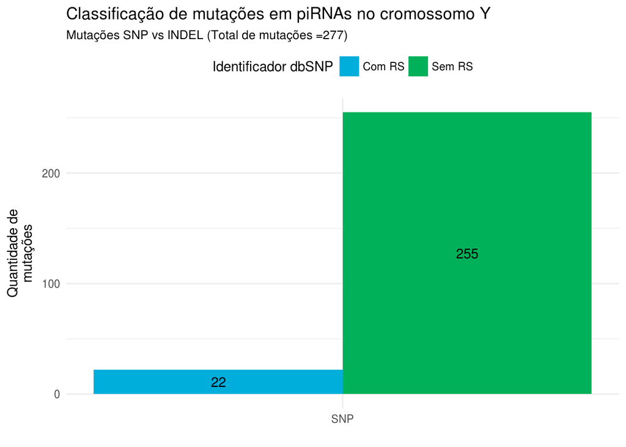

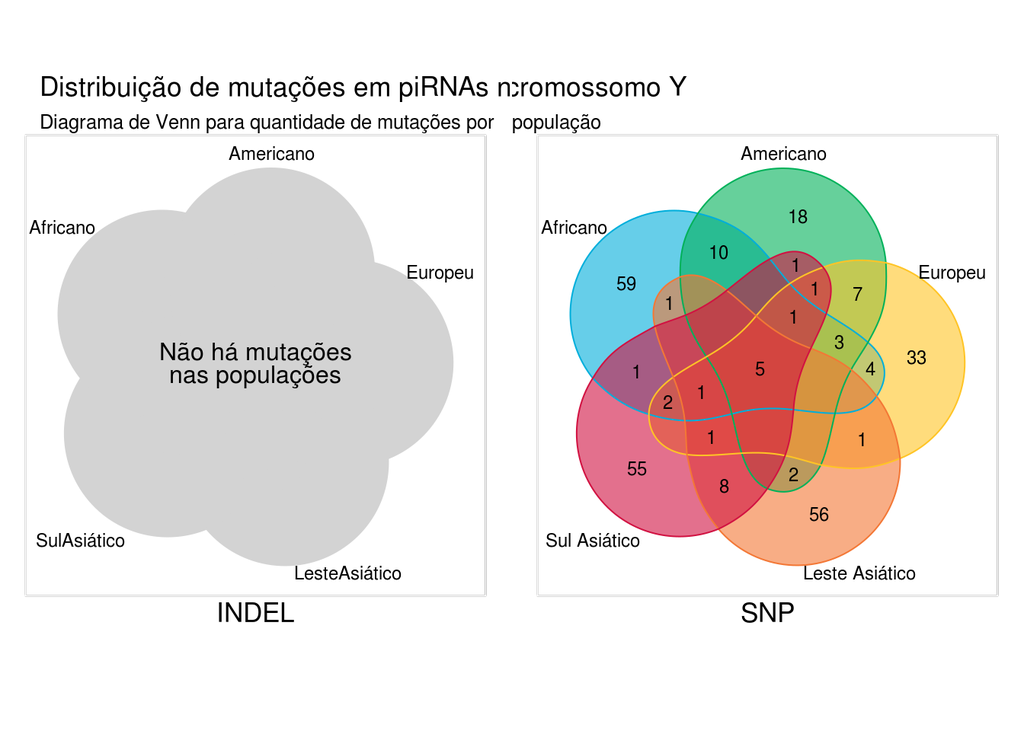

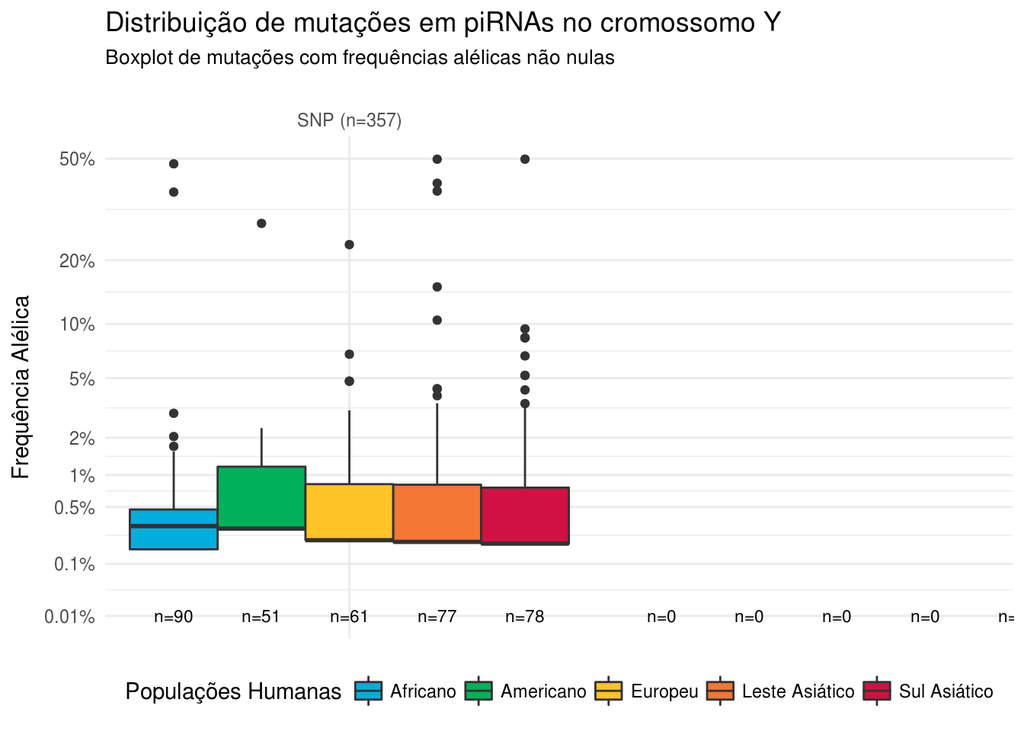

## Relatório de execução para chrY

Este relatório foi obtido a partir de um modelo pré-definido `reportPirnaGDF.Rmd`, que apresenta um conjunto diversificado de parâmetros cujo intuito é reutilizar um mesmo modelo de relatório para diferentes valores de entrada atribuidos. Os nomes, tipos e valores padrões desses parâmetros são declarados na seção YAML desse modelo, como definidos a seguir:

```r
#' Modelo para o cabeçalho YAML do arquivo .Rmd
---
title: 'Relatório de Execução de piRNAcalc para o `r params$chrom`'
author: 'José Roberto Sobrinho Lima'
date: "`r format(Sys.time(), '%d de %B de %Y')`"
params:
  pirnaDir: ".../path/to/piRNA_directory"
  gitHubDir: ".../path/to/gitHub_local_repos_directory"
  pirnaObject: "name_object_pirnaGDF.rds"
  fileRout: "name_file.Rout"
  fileRmd: "name_file.Rmd"
  chrom: "chr[1-22;X;Y]"
---
```

O resultado final foi um relatório em formato `html` produzido de acordo com o seguinte código:

```r
#' Modelo para a obtenção do relatório de execução
rmarkdown::render(
  input         = ".../path/to/gitHub_local_repos_directory/name_file.Rmd",
  output_dir    = ".../path/to/piRNA_directory"
  output_file   = "name_file.html",
  output_format = "html_document",
  encoding      = "UTF-8",
  params        = list(
    pirnaDir    = ".../path/to/piRNA_directory",
    gitHubDir   = ".../path/to/gitHub_local_repos_directory",
    pirnaObject = "name_object_pirnaGDF.rds",
    fileRout    = "name_file.Rout",
    fileRmd     = "name_file.Rmd",
    chrom       = "chr[1-22;X;Y]"
  )
)
```

## Tempos de Execução de piRNAcalc()

Os tempos de execução do código foram obtidos com base no pacote `tictoc` [(IZRAILEV, 2014)](http://github.com/collectivemedia/tictoc) e armazenados no arquivo `piRNAcalc_chrY.Rout`. Ao todo, foram calculados os tempos de execução em 3 momentos distintos do código:

1. Tempos de execução para tratamento do arquivo VCF:
- Leitura do arquivo VCF: `19.272 sec elapsed`;
- Limpeza dos atributos *INFO* do arquivo VCF: `1.879 sec elapsed`;
- Tratamento de obervações com múltiplas mutações: `0.117 sec elapsed`;
- Cálculo dos ACs de cada população: `18.328 sec elapsed`.
2. Tempos de execução para tratamento do arquivo GFF:
- Leitura do arquivo GFF: `4.782 sec elapsed`;
- Limpeza do campo *attributes* do arquivo GFF: `0.157 sec elapsed`.
3. Tempos de execução para quantificação das mutações nas 5 regiões (5x):
- Região Adjacente -1000:
  - Atualização da tabela **pirnaData** e da lista **mutData** para compor a classe `InfoPirna`: `80.248 sec elapsed`.
- Região Adjacente 5’:
  - Atualização da tabela **pirnaData** e da lista **mutData** para compor a classe `InfoPirna`: `78.614 sec elapsed`.
- Região de piRNA:
  - Atualização da tabela **pirnaData** e da lista **mutData** para compor a classe `InfoPirna`: `60.224 sec elapsed`.
- Região Adjacente 3’:
  - Atualização da tabela **pirnaData** e da lista **mutData** para compor a classe `InfoPirna`: `60.184 sec elapsed`.
- Região Adjacente +1000:
  - Atualização da tabela **pirnaData** e da lista **mutData** para compor a classe `InfoPirna`: `56.86 sec elapsed`.

O tempo total de execução do código foi estimado em `383.921 sec elapsed`.

## Considerações finais

Os tempos de execução apresentados anteriormente fornecem um panorama abrangente da demanda computacional exigida pelo código e pelos arquivos por ele tratados.

Por fim, esses dados também permitem que modificações realizadas no código possam ter uma avaliação mais consistente em termos de performace e desempenho.